# Statistical Methods in Data Science

Homework 2

Aguanno Irene - Barboni Alessio

A.Y. 2021-2022

In game theory, the **Shapley value** is a rule useful for fairly dividing up the productive value generated by some set of individuals (a *coalition*) among its members. It is based on Lloyd Shapley’s idea that the members of a coalition should receive a payment that is proportional to their marginal contribution.

# Exercises

## 1. Introductory

First and foremost, we find the Shapley values for the three players of a simple game that requests them to collaborate in order to save working hours. The players, which we call **A**, **B** and **C**, form a coalition *C* such that ν(**A**)=ν(**B**)=ν(**C**)= 0 and ν(**ABC**)= 4, with ν(*C*)={# of hours potentially saved by well organized coalition}.

We end up with the following table showing the value brought to the coalition by each player while the *grand coalition* (i.e., the coalition formed by all players) gets formed.

| Permutations | Player_A | Player_B | Player_C |
| --- | --- | --- | --- |
| ABC | 0 | 2 | 2 |
| ACB | 0 | 4 | 0 |
| BAC | 2 | 0 | 2 |
| BCA | 2 | 0 | 2 |
| CAB | 0 | 4 | 0 |
| CBA | 2 | 2 | 0 |

According to the table, then, we obtain the following Shapley values:

$\psi (A) = 6/6 = 1$

$\psi (B) = 12/6 = 2$

$\psi (C) = 6/6 = 1$.

Such results seem reasonable, since **B** works during the hours in the middle of the day and can therefore cover more shifts. We also check that $\psi(A)+\psi(B)+\psi(C)=v(ABC)= 4$.

## 2.Probabilistic

Now we have many more players to handle, but the procedure remains essentially the same. The Shapley Value is still calculated as the mean of differences between the value of the characteristic function of a coalition containing a certain player X, and the value for the same coalition but without player X (i.e., it aims at measuring the contribution of a single player, X, to that specific coalition). In the shapley table, the coalition members depend on the permutations of the players and on the player itself for whom we are calculating the Shapley Value. The coalitions that form for the X-th column are the result of slicing every permutation array up to element X, that is then splitted as described above.

Importing libraries and the dataset:

```r
library(combinat)
load("C:/Users/alema/Downloads/char_fun.RData")
```

Initializing variables:

```r
p <- 12
myPlayers = c(1,2,3) # chosen arbitrarily
eps <- 0.01
alpha <- 0.05
gamma <- 1-alpha
```

We chose a 95% confidence level, and an epsilon of 1%.

Approximating the boundaries $(a, b)$ for Shapley Values:

The tighter the boundaries, the smaller the sample size needed for a good enough approximation would be. Here also we want to find an approximation for $a$ and $b$, since finding the real boundaries would be at least as costly as finding the shapley value itself. Of course, these bounds must be inclusive, i.e., they must contain every possible value of the shapley value domain (otherwise the sample size would be too small, and Hoeffding approximation would have no guarantee to hold). For this reason we have excluded those greedy approaches that try converging to a local minimum/maximum, given that there is not guarantee that they would end up containing every possible element.

To avoid this problem, we opted for finding the smallest/largest difference for each coalition size pair (i.e., (size=2,size=1), …, (size=12,size=11)), in this way the bounds would surely contain each possible value and would probably end up being even looser than needed. Given that there are 12 positions that player $X$ can take in the array, for each of those, associated with a different extremum, there are $11 \choose i$ different entries in the shapley table, were $i$ represents the number of players in the smaller coalition (since the #possibilities depends on the #combinations of the 11 other players over the i-1 array places).

```r
a<-0
for (i in (2:(p-1))){
  nChooseK <- prod(c((p-1):c(p-i-1+1, i-1+2)[match(max(p-1-i, i), c(p-i-1, i))] ))/factorial(min(p-i-1, i))
  if (i==(p-1)) nChooseK=1
  a<-a+(max(0, min(char_fun[[i]]) - max(char_fun[[(i-1)]])))*nChooseK
}
a<-floor(a/(2**(p-1)-1))
sprintf("The lower bound approximation, a, for Shapley Values is: %s", a)
```

```
## [1] "The lower bound approximation, a, for Shapley Values is: 0"
```

```r
b<-0
for (i in (2:(p-1))){
  nChooseK <- prod(c((p-1):c(p-i-1+1, i-1+2)[match(max(p-1-i, i), c(p-i-1, i))] ))/factorial(min(p-i-1, i))
  if (i==(p-1)) nChooseK=1
  b<-b+(max(char_fun[[i]]) - min(char_fun[[(i-1)]]))*nChooseK
}
b<-ceiling(b/(2**(p-1)-1))
sprintf("The upper bound approximation, b, for Shapley Values is: %s", b)
```

```
## [1] "The upper bound approximation, b, for Shapley Values is: 14"
```

Calculating the sample size needed for Hoeffding approximation:

```r
M_star <- ceiling(((b - a)**2)/(2 * eps**2) * log(2/(alpha)))
sprintf("The required sample size for our approximation is: %s", M_star)
```

```
## [1] "The required sample size for our approximation is: 3615102"
```

Compute the first N permutations of $p!$:

Since there are 12 different players, its factorial would be a really large number (i.e., $4.79e+08$). Hence, for efficiency reasons, instead of computing first all the permutations of the 12 players and then take only the first N (or better, M_star that is $3.61e+6$), we can simply stop the algorithm as soon as it computes the first M_star permutations. This is true because we need just one estimate for each one of the three players, if we needed more we would have needed all the permutations instead, plus the function “sample” for shuffling them to get different M_star samples at each iteration. Anyway, in order to calculate the first N permutations, we decided to modify the “permn” function from $R$’s “combinat” library. The whole function is the one below, the changes that we made are the ones commented.

```r
firstNPerm <- function (x, fun = NULL, ...) #Takes the first N permutations of p!
{
  if (is.numeric(x) && length(x) == 1 && x > 0 && trunc(x) ==
      x)
    x <- seq(x)
  n <- length(x)
  nofun <- is.null(fun)
  out <- vector("list", M_star) #gamma(n+1) changed into M_star, i.e. the desired output size
  p <- ip <- seqn <- 1:n
  d <- rep(-1, n)
  d[1] <- 0
  m <- n + 1
  p <- c(m, p, m)
  i <- 1
  use <- -c(1, n + 2)
  clt<-0 # added a control variable to end the loop after M_star iterations
  while (m != 1) {
    if (clt==M_star) break # added a control condition to end the loop
    clt<-clt+1 # added an expression to increase the iterations counter
    out[[i]] <- if (nofun)
      x[p[use]]
    else fun(x[p[use]], ...)
    i <- i + 1
    m <- n
    chk <- (p[ip + d + 1] > seqn)
    m <- max(seqn[!chk])
    if (m < n)
      d[(m + 1):n] <- -d[(m + 1):n]
    index1 <- ip[m] + 1
    index2 <- p[index1] <- p[index1 + d[m]]
    p[index1 + d[m]] <- m
    tmp <- ip[index2]
    ip[index2] <- ip[m]
    ip[m] <- tmp
  }
  out[1:M_star]
}
permutations <- firstNPerm(c(1:12))
```

### Hoeffding Estimate of Shapley Values:

Here we calculate the shapley values of the first three players, that we arbitrarily chose.

```r
I <- c(0,0,0)
for (i in (1:M_star)){
  iPerm <- permutations[i][[1]]
  for (player in myPlayers){
    if (length(iPerm[1:(match(player, iPerm))])==1) next
    key <-sort(iPerm[1:(match(player, iPerm)-1)])
    key1 <- ""
    for (i in (1:length(key))){
      key1<-paste(key1,"-",key[i],sep="")
    }
    key1<-substr(key1, 2, nchar(key1))

    key <-sort(iPerm[1:(match(player, iPerm))])
    key2 <- ""
    for (i in (1:length(key))){
      key2<-paste(key2,"-",key[i],sep="")
    }
    key2<-substr(key2, 2, nchar(key2))
    I[player] <- I[player] + (char_fun[[length(key)]][[key2]] - char_fun[[(length(key)-1)]][[substr(key1, 0, nchar(key1))]])
  }
}
cat("Shapley Values Approximations:", "\n","Player 1:", I[1]/M_star,"\n","Player 2:", I[2]/M_star,"\n","Player 3:", I[3]/M_star)
```

```
## Shapley Values Approximations:
##  Player 1: 1.726239
##  Player 2: 6.126664
##  Player 3: 6
```

As we can see above, Player 1’s shapley value is quite smaller with respect to the one of the other two. A reasonable explaination might be related to the players’ working hours. Player 1 is able to work from 12.00 to 17.00 non-stop, but cannot from 9.00 to 12.00. The latter time period is much more requested in some sense by the possible coalitions that may form, since there are 16 other holes from other players’ working schedule. Player 2 instead has the highest shapley value of the three, its only flaw that is penalizing him probably is the 16.00-17.00 hole. Player 3 is in the middle, as one could have expected.

### Hoeffding Confidence Intervals:

```r
I<-c(1.726239, 6.126664, 6)
t_alpha <- sqrt((b-a)**2/(2*M_star) * log(2/alpha))
i<-1
for (shap in I){
  print(eval(sprintf("Player %s confidence interval is: (%s,%s)",i,round(shap-t_alpha,2),round(shap+t_alpha,2))))
  i<-i+1
}
```

```
## [1] "Player 1 confidence interval is: (1.72,1.74)"
## [1] "Player 2 confidence interval is: (6.12,6.14)"
## [1] "Player 3 confidence interval is: (5.99,6.01)"
```

### Bonus Point

The code below aims at building the characteristic function for a generic game of this type. To test if it is working we will use the provided working schedule that we have rewritten in a csv file.

```r
library(stringr)
df <- read.csv("bonus.csv", sep=";")
df <- df[-c(13:15),-c(1,10:14)]
df
```

```
##    hour1 hour2 hour3 hour4 hour5 hour6 hour7 hour8
## 1     No    No    No   Yes   Yes   Yes   Yes   Yes
## 2    Yes   Yes   Yes   Yes   Yes   Yes   Yes    No
## 3     No   Yes   Yes   Yes   Yes   Yes   Yes    No
## 4     No    No    No    No    No   Yes   Yes   Yes
## 5     No    No    No    No   Yes   Yes   Yes    No
## 6     No    No   Yes   Yes   Yes   Yes   Yes    No
## 7    Yes   Yes   Yes   Yes    No    No    No    No
## 8    Yes   Yes   Yes    No    No    No   Yes    No
## 9     No   Yes   Yes   Yes   Yes    No    No    No
## 10    No    No   Yes   Yes   Yes   Yes    No   Yes
## 11   Yes   Yes    No    No    No   Yes   Yes    No
## 12    No    No    No   Yes    No    No   Yes   Yes
```

Besides some string manipulation for creating the keys for the characteristic function, this function computes its values for a certain combination considering “Yes” and “No” as 1s and 0s, to be able to easily take the row sum between players in each coalition. Whenever the resulting row/array has elements larger than 1 it means that some hours have been saved. Hence, it computes the sum of these larger-than-one values and then subtracts the number of summed elements (since in the end a player of the coalition must do the work in each of these time slots).

```r
charFunCalculator <- function(timeSchedule){
numPlayers <- nrow(df)
numHours <- ncol(df)
colnames(df)<-NULL
rownames(df)<-NULL
charFun <- list()
for (i in (1:numPlayers)){
  combs <- combn((1:numPlayers), i)
  if (i==numPlayers) combs<-matrix(combn((1:numPlayers), numPlayers), ncol = 1)
  tempNames <- c()
  tempValues <- c()
  for (j in (1:ncol(combs))){
    key <- ""
    coalition <- combs[,j]
    hoursSaved <-c(rep(0, numHours))
    for (player in coalition){
      key<-paste(key, player,"-", sep="")
      df[player,1:numHours] <- str_replace_all(df[player,1:numHours], "Yes", "1")
      df[player,1:numHours] <- strtoi(str_replace_all(df[player,1:numHours], "No", "0"))
      hoursSaved <- hoursSaved+as.numeric(df[player,1:numHours])
    }
    key <- substr(key, 1, nchar(key)-1)
    tempNames <- c(tempNames, key)
    tempValues <- c(tempValues, sum(hoursSaved[hoursSaved>1])-length((hoursSaved[hoursSaved>1])))
  }
  names(tempValues) <- tempNames
  charFun <- append(charFun, list(tempValues))
}
return(charFun)
}
charFun <- charFunCalculator(df)
```

Let’s check now if it is equal to the char_fun that was provided by the homework.

```r
for (i in (1:12)){
  print(all(charFun[[i]]==char_fun[[i]]))
}
```

```
## [1] TRUE
## [1] TRUE
## [1] TRUE
## [1] TRUE
## [1] TRUE
## [1] TRUE
## [1] TRUE
## [1] TRUE
## [1] TRUE
## [1] TRUE
## [1] TRUE
## [1] TRUE
```

## 3. Statistical

```r
library(readxl)
library(quantmod)
library(confintr)
library(data.table)
library(igraph)
library(GGally)
library(boot)
```

### 3.1

First of all, we create our portfolio. We do so by collecting assets from different GICS sectors. Our expectation is that the marginal correlation graphs will show stocks from the same sectors clustering together, as they supposedly interact more with each other.

```r
data_env <- new.env()
stocks <- read_excel("aziende.xlsx")

# Use getSymbols to load data into the environment
today <- Sys.Date()
getSymbols(Symbols = stocks$Symbol,src = "yahoo", from = "2020-01-01", to = today,
           frequency = "daily", env = data_env, auto.assign = TRUE)
```

| Symbol | Company Name | Sector |
| --- | --- | --- |
| AAPL | Apple Inc. Common Stock | Technology |
| AMOV | America Movil, S.A.B. de C.V. Class A American Depositary Shares | Public Utilities |
| AMT | American Tower Corporation (REIT) Common Stock | Finance |
| AMX | America Movil, S.A.B. de C.V. American Depository Receipt Series L | Public Utilities |
| ARE | Alexandria Real Estate Equities Inc | Real Estate |
| AXP | American Express Company Common Stock | Finance |
| BAC | Bank of America Corporation Common Stock | Finance |
| BBL | BHP Group PlcSponsored ADR | Energy |
| BLK | BlackRock, Inc. Common Stock | Finance |
| BP | BP p.l.c. Common Stock | Energy |
| BX | Blackstone Inc. Common Stock | Finance |
| BXP | Boston Properties | Real Estate |
| C | Citigroup, Inc. Common Stock | Finance |
| COP | ConocoPhillips Common Stock | Energy |
| CVX | Chevron Corporation Common Stock | Energy |
| D | Dominion Energy, Inc. Common Stock | Public Utilities |
| DUK | Duke Energy Corporation (Holding Company) Common Stock | Public Utilities |
| E | ENI S.p.A. Common Stock | Energy |
| ENB | Enbridge Inc Common Stock | Energy |
| EOG | EOG Resources, Inc. Common Stock | Energy |
| EPD | Enterprise Products Partners L.P. Common Stock | Public Utilities |
| EQIX | Equinix | Real Estate |
| EQNR | Equinor ASA | Energy |
| ESS | Essex Property Trust, Inc. | Real Estate |
| EXC | Exelon Corporation Common Stock | Public Utilities |
| FB | Meta Platforms, Inc. Class A Common Stock | Technology |
| GOOG | Alphabet Inc. Class C Capital Stock | Technology |
| GOOGL | Alphabet Inc. Class A Common Stock | Technology |
| GS | Goldman Sachs Group, Inc. (The) Common Stock | Finance |
| HDB | HDFC Bank Limited Common Stock | Finance |
| HSBC | HSBC Holdings, plc. Common Stock | Finance |
| JPM | JP Morgan Chase & Co. Common Stock | Finance |
| KIM | Kimco Realty | Real Estate |
| MS | Morgan Stanley Common Stock | Finance |
| MSFT | Microsoft Corporation Common Stock | Technology |
| NEE | NextEra Energy, Inc. Common Stock | Public Utilities |
| NGG | National Grid Transco, PLC National Grid PLC (NEW) American Depositary Shares | Public Utilities |
| NVDA | NVIDIA Corporation Common Stock | Technology |
| PBR | Petroleo Brasileiro S.A.- Petrobras Common Stock | Energy |
| PTR | PetroChina Company Limited Common Stock | Energy |
| SCHW | Charles Schwab Corporation (The) Common Stock | Finance |
| SLG | SL Green Realty | Real Estate |
| SNP | China Petroleum & Chemical Corporation Common Stock | Energy |
| SO | Southern Company (The) Common Stock | Public Utilities |
| SPG | Simon Property Group Inc | Real Estate |
| TMUS | T-Mobile US, Inc. Common Stock | Public Utilities |
| TTE | TotalEnergies SE | Energy |
| UDR | UDR Inc | Real Estate |
| VTR | Ventas Inc | Real Estate |
| VZ | Verizon Communications Inc. Common Stock | Public Utilities |
| WFC | Wells Fargo & Company Common Stock | Finance |
| WM | Waste Management, Inc. Common Stock | Public Utilities |
| XOM | Exxon Mobil Corporation Common Stock | Energy |

For each stock, we download the daily closing prices (adjusted by dividends) from January 1st, 2020 until today (December 24th, 2021). This results in exactly 500 observations for each stock. Finally, we compute a matrix $X$ whose entries are calculated as $x_{t,j} = log(c_{t,j}/c_{t−1,j})$ (*Eq. 2*), with $c_{t,j}$ being the closing price of stock $j$ on day $t$. $X$ will be the starting point of our analysis.

```r
# Extract closing price column from each object
close_list <- lapply(data_env, Cl)
# Merge each list element into one object
close <- do.call(merge, close_list)
head(close)
```

```
##            BXP.Close HDB.Close BAC.Close HSBC.Close AMT.Close EPD.Close
## 2020-01-02    135.58     63.70     35.64      39.37    228.50     28.13
## 2020-01-03    136.64     62.01     34.90      38.76    228.61     28.40
## 2020-01-06    137.60     60.91     34.85      38.63    228.55     28.70
## 2020-01-07    135.21     60.69     34.62      38.34    223.68     28.72
## 2020-01-08    134.49     61.34     34.97      38.25    225.62     28.64
## 2020-01-09    134.56     62.52     35.03      38.50    226.47     28.56
##            NGG.Close EQIX.Close AMX.Close XOM.Close SO.Close COP.Close
## 2020-01-02     62.34     579.35     16.26     70.90    62.62     65.46
## 2020-01-03     62.20     585.12     16.24     70.33    62.56     65.70
## 2020-01-06     62.17     584.48     16.16     70.87    62.81     66.48
## 2020-01-07     61.90     581.88     15.92     70.29    62.62     66.48
## 2020-01-08     61.62     583.80     15.86     69.23    62.60     64.94
## 2020-01-09     61.20     588.99     15.88     69.76    63.26     66.07
##            SNP.Close PTR.Close ENB.Close PBR.Close VTR.Close ESS.Close MS.Close
## 2020-01-02     61.22     51.11     39.71     16.27     56.39    298.28    52.04
## 2020-01-03     61.52     51.62     39.64     15.99     57.07    301.20    51.20
## 2020-01-06     61.95     53.37     40.01     16.22     57.66    300.00    51.02
## 2020-01-07     61.66     52.86     39.74     16.06     57.18    296.33    50.92
## 2020-01-08     60.77     51.77     39.91     15.70     56.90    298.04    51.57
## 2020-01-09     61.60     52.55     39.84     15.75     56.57    299.46    52.06
##            C.Close GS.Close D.Close MSFT.Close TTE.Close E.Close ARE.Close
## 2020-01-02   81.23   234.32   81.96     160.62     55.27   31.48    159.73
## 2020-01-03   79.70   231.58   81.76     158.62     55.47   31.56    160.64
## 2020-01-06   79.45   233.95   82.39     159.03     56.51   32.12    161.03
## 2020-01-07   78.76   235.49   82.21     157.58     56.19   31.94    155.76
## 2020-01-08   79.36   237.76   81.69     160.09     55.85   31.44    157.83
## 2020-01-09   80.08   242.60   81.92     162.09     55.88   31.71    157.27
##            NEE.Close AMOV.Close SLG.Close VZ.Close DUK.Close GOOGL.Close
## 2020-01-02   59.6550      16.08  91.56540    61.05     90.34     1368.68
## 2020-01-03   60.0800      16.11  91.92585    60.40     90.40     1361.52
## 2020-01-06   60.3800      16.17  93.34707    60.27     90.84     1397.81
## 2020-01-07   60.3275      15.92  92.21421    59.60     90.27     1395.11
## 2020-01-08   60.3000      15.81  92.63646    59.71     90.40     1405.04
## 2020-01-09   60.7725      15.78  93.03810    58.85     90.62     1419.79
##            AAPL.Close BBL.Close WM.Close BP.Close AXP.Close NVDA.Close FB.Close
## 2020-01-02    75.0875     47.34   114.22    38.14    125.85    59.9775   209.78
## 2020-01-03    74.3575     46.88   115.33    38.83    124.60    59.0175   208.67
## 2020-01-06    74.9500     46.81   115.93    39.85    124.06    59.2650   212.60
## 2020-01-07    74.5975     46.94   116.01    39.43    123.41    59.9825   213.06
```

[output cut: 8 more lines]

```
## 2020-01-09      20.67     45.66     52.73     46.15      79.81     88.25
##            SCHW.Close SPG.Close GOOG.Close BX.Close CVX.Close BLK.Close
## 2020-01-02      48.23    145.09    1367.37    55.80    121.43    508.98
## 2020-01-03      47.01    145.35    1360.66    56.00    121.01    503.57
## 2020-01-06      47.34    146.11    1394.21    55.90    120.60    504.00
## 2020-01-07      47.62    144.45    1393.34    55.90    119.06    507.22
## 2020-01-08      47.91    145.40    1404.32    56.74    117.70    507.10
## 2020-01-09      48.11    144.23    1419.83    57.85    117.51    513.10
##            JPM.Close KIM.Close
## 2020-01-02    141.09     19.60
## 2020-01-03    138.34     19.81
## 2020-01-06    138.23     20.07
## 2020-01-07    135.88     19.83
## 2020-01-08    136.94     19.75
## 2020-01-09    137.44     19.33
```

```r
# take the difference between log(x_j,t) and log(x_j-1, t)
X <- diff(log(close))
# remove first row since NAs are generated
X <- X[-1]
# transform to dataframe
X <- as.data.frame(X)
# order columns by name
X <-X[,order(names(X) )]
stocks$Symbol <- colnames(X)
# remove .Close from name
stocks$Symbol <-  gsub(".Close", "", stocks$Symbol)
```

### 3.2

We now estimate the Pearson-based marginal correlation graph over stocks, starting from $X$. To this end, we first compute asymptotic Normal-based confidence intervals (with alpha left to the default value of 5%) between all possible pairs of stocks in our portfolio and - when the result obtained is statistically significant (i.e., the confidence interval does not contain 0) - we store it in a new matrix.

```r
# initialize matrix that will contain significant Pearson correlation coefficients
Pearsons <- matrix(NA,ncol=length(stocks$Symbol),nrow=length(stocks$Symbol))
rownames(Pearsons) <- stocks$Symbol
colnames(Pearsons) <- stocks$Symbol

# for each pair of stocks i, j
for(i in 1:length(stocks$Symbol)){for(j in i:length(stocks$Symbol)){
  # if the confidence interval for the pearson coefficient does not contain the zero
  if (!(ci_cor(X[,c(i,j)])$interval[1] < 0 & ci_cor(X[,c(i,j)])$interval[2]>0)) {
    # add the coefficient to the (i,j)-th position in the matrix
    Pearsons[i,j] <- cor(X[,i], X[,j])
  }
}}
```

```r
Pearsons <- data.frame(Pearsons)
```

### 3.3

Now that we have the theoretical procedure to build our Pearson-based confidence intervals, it’s time to visualize some results. The marginal correlation graph is created by putting an edge between stocks $j$ and $k$ when $|\rho(j,k)|≥ \epsilon$, with $\rho$ being the Pearson correlation coefficient obtained earlier and $\epsilon$ a threshold between 0 and 1.

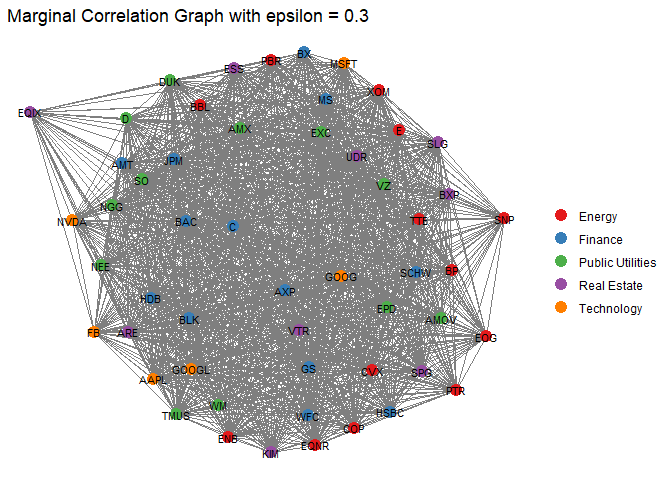

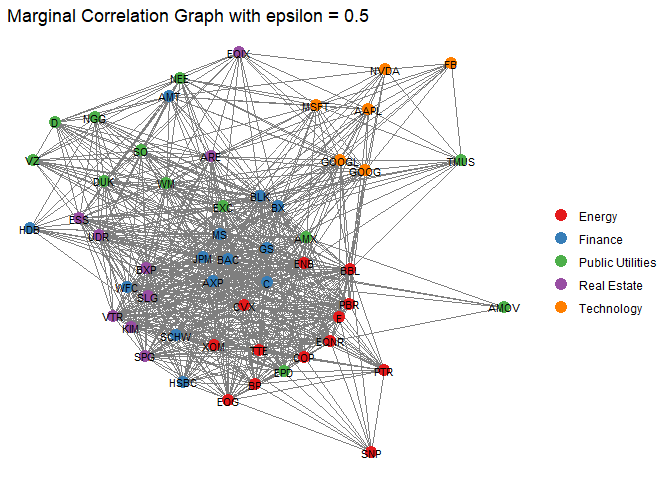

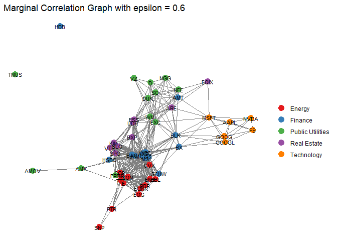

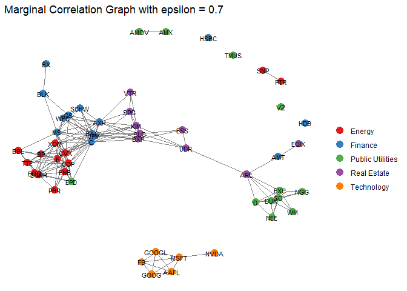

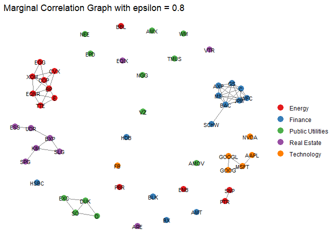

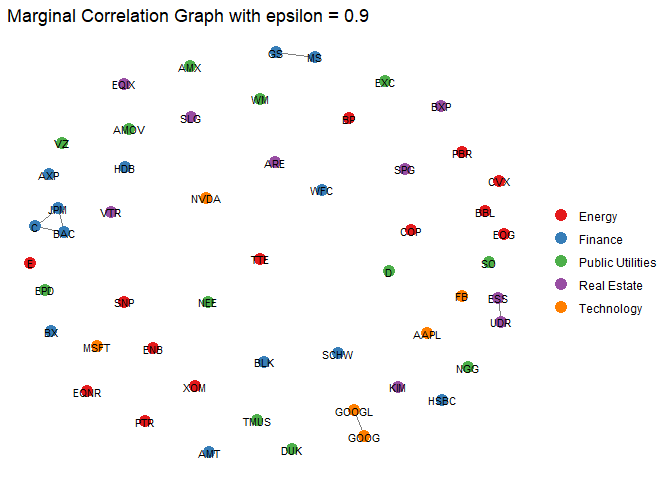

Cool! As expected, stocks from companies belonging to the same GICS sector tend to have higher correlations and thus appear clustered together, especially for $\epsilon>0.5$.

A few nodes seem to be out of place, like AMT (which belongs to the Finance sector, but is linked to two companies from the Real Estate sector) in the epsilon = 0.7 graph or EPD (from Public Utilities, but connected to companies of the Energy field) in the same graph. Still, upon further inspection, we discover that AMT (American Tower Corporation) actually is [“one of the largest global Real Estate Investment Trusts (REITs)”](https://www.americantower.com/company/) and EPD (Enterprise Products Partners) is [“one of the largest Midstream Oil and Gas companies in North America”](https://www.enterpriseproducts.com/), so it makes sense for them to be clustered together with Real Estate and Energy companies, respectively.

It is also nice to observe that with $\epsilon>0.8$ only stocks of the same sector are connected.

### 3.4

Now that we gained insight on how our stocks are correlated, we proceed with the estimation of the Shapley values $\psi(j)$ for each stock $j$. Since computing the Shapley attribution may be prohibitive when the number of players (here, stocks) is large, we approximate them via a bootstrap simulation.

We experiment with two different values for $\omega$ (a smaller one, 0.1, and a larger one, 5) and two types of confidence intervals (pivotal and normal).

```r
# apply formula for the Shapley values
shapley <- function(x, omega = 1){
  ### param x: matrix with the data
  ### param omega: positive weight

  # compute expected value of each stock
  ex <- apply(x, 2, mean)
  covariance = cov(x)
  # sum the covariances
  c <- apply(covariance, 1, sum)
  # apply formula
  sh = ex + omega * c
  return(sh)
}
```

```r
# Estimator
shap <- shapley(X, omega = 0.1)
```

```r
set.seed(42)
# number of bootstrap iterations
B      <- 1000
# initialize matrix containing bootstrpped replicates
shboot <- matrix(NA, ncol = dim(X)[2], nrow = B)
colnames(shboot) <- stocks$Symbol

# Main loop
for (b in 1:B){
    idx = sample(1:dim(X)[1], dim(X)[1],
               replace = TRUE)
    xboot = X[idx,]
    shboot[b,] = shapley(xboot, omega = 0.1)
}
```

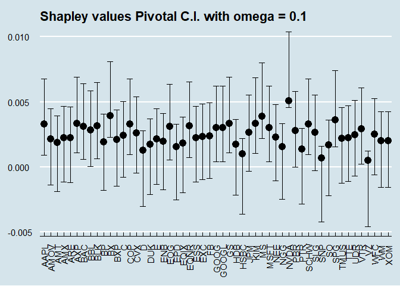

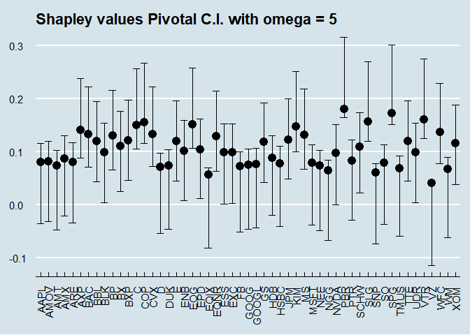

```r
# Pivotal
alpha <- 0.05
# compute pivotal confidence intervals
interv <- matrix(NA, nrow = 2, ncol = length(stocks$Symbol))
interv[1,] <- 2*shap - quantile(shboot, 1 - alpha/2)
interv[2,] <- 2*shap - quantile(shboot, alpha/2)

colnames(interv) <- stocks$Symbol
rownames(interv) <- c("Lower","Upper")
```

From the two graphs above, what really strikes the eye is the difference in scale. By increasing $\omega$, we get much larger confidence intervals. This is reasonable since - as can be seen in Eq. 1 - $\omega$ amplifies the variability of the stock. Therefore, the width of the confidence intervals reflects the level of risk aversion of the stocks’ holder. A larger confidence interval - implying a larger $\omega$ - expresses a greater aversion to risk.

Another method to construct confidence intervals is with Normal intervals. To build them correctly, one should already have knowledge about the asymptotic Gaussianity of the estimator, otherwise the interval is not accurate. Since in section 3.2 of this report we already made this assumption, we repeat the analysis in this new context.

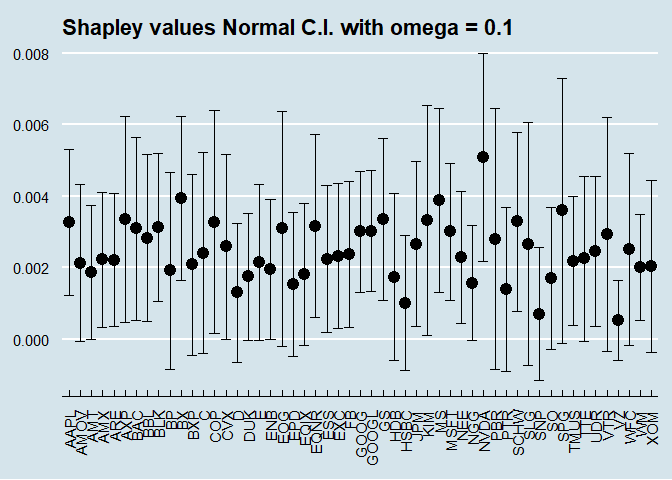

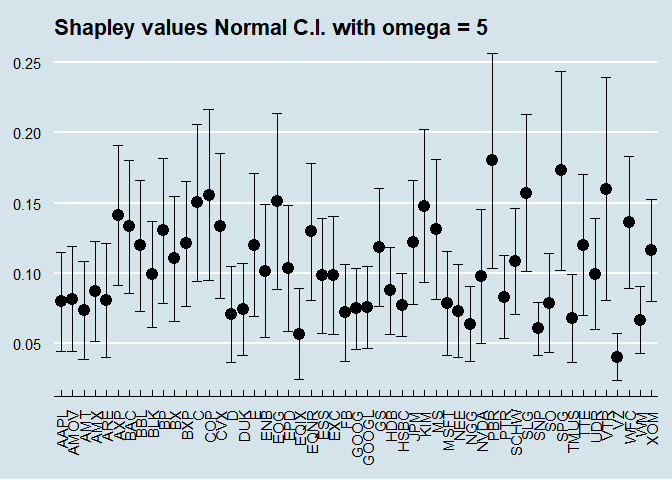

```r
# Normal
shap <- shapley(X, omega = 0.1)

set.seed(42)
B      <- 1000
shboot <- matrix(NA, ncol = dim(X)[2], nrow = B)
colnames(shboot) <- stocks$Symbol

# Main loop
for (b in 1:B){
    idx = sample(1:dim(X)[1], dim(X)[1],
               replace = TRUE)
    xboot = X[idx,]
    shboot[b,] = shapley(xboot, omega = 0.1)
}

# get standard error
sdt <- apply(shboot,2,sd)
alpha <- 0.05
# compute normal-based confidence intervals
interv <- matrix(NA, nrow = 2, ncol = length(stocks$Symbol))
interv[1,] <- shap - qnorm(1 - alpha/2)*sdt
interv[2,] <- shap - qnorm(alpha/2)*sdt

colnames(interv) <- stocks$Symbol
rownames(interv) <- c("Lower","Upper")
```